# Typst in production: turning data into deliverables

Joseph Barbier - *Typst meetup, 2026*

# *Typst* Data science in production

## This is not about Typst*…

*(*thanks to Typst!)*

[figure not shown]

- I don’t have any tips
- No best-practice recommendations
- TLDR: if you’re here, you likely know more Typst than me!

## … it’s all about reproducibility

- Will it work on someone else’s machine?
- Will it work 1 year from now?
- Will it work with new data?
- Can someone less technical run it too?

## About

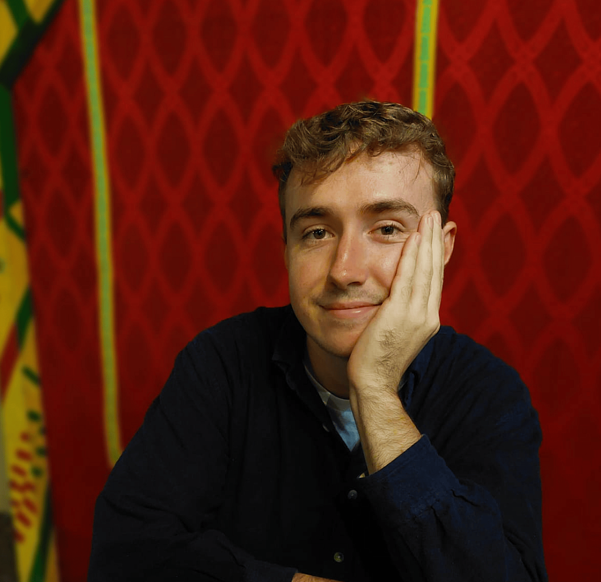

*Joseph*

barbierjoseph.com

ysunflower.com

Consulting

Open source

Data(viz)

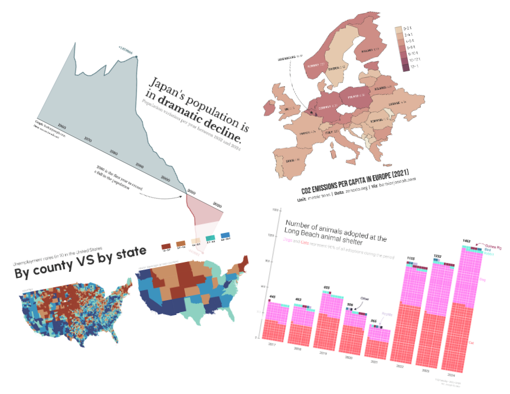

## Projects

- 1 - Typst on the client
- 2 - Typst on the server

# 1 - Child vaccination in the US

## Project description

[figure not shown]

[figure not shown]

*made with Clarity Data Studio*

- 50 reports (1 per US state)
- **Stack**: R + Quarto

## Quarto

## Reports

[figure not shown]

## How it works

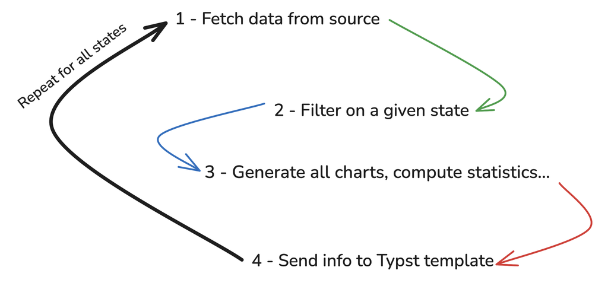

## Now

Single R script that:

- installs dependencies
- renders 50 reports
- puts them into a Google Drive

## Learn more about this project

Code + Data + Doc

github.com/claritydatastudio/state-immunization-reports

# 2 - Assessing psychosocial risks among French workers

## Context: psychosocial risk assessment at work

- French employers are legally required to assess psychosocial risks, but:
  - enforcement is limited
  - practical guidance is often unclear
  - external consulting can be expensive

[figure not shown]

## Approach

- Run an anonymous survey across the company
- Build a report from the responses

That’s the core idea.

[figure not shown]

## In practice, it’s more complex…

- Survey is long (70+ questions)
- Results must be easy to consume (charts, summary, etc.)
- Fully anonymous
- Actionable (what should we do next?)

## Solution

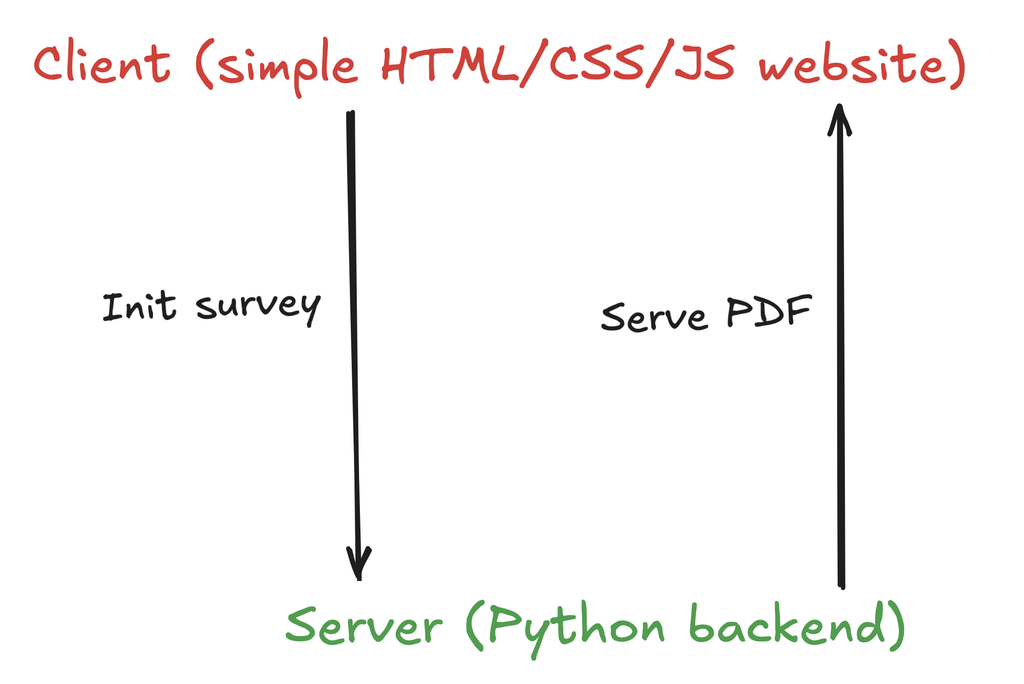

## What about Typst?

We run Typst on the backend using typst-py

```python
import json
import typst

# ID of the company
companyid = get_company_id()

# create PNG files for the report
generate_all_chart(companyid)

# summary, what to do next, etc
insights = generate_insights(companyid)

sys_inputs = {
  "companyid": json.dumps(companyid)
  "insights": json.dumps(insights)
}
typst.compile(
    "src/document/template.typ",
    output="report.pdf",
    sys_inputs=sys_inputs,
)
```

## Tech stack (PoC, not stable)

- Backend: Python (FastAPI for the API, matplotlib for dataviz, polars & sqlalchemy for data, …)
- Frontend: native HTML/CSS/JS
- DB: Postgres

–> Future stack (?):

- React/Next on the frontend, for simplicity
- Rust (framework TBD) for the backend because performance and memory usage can be issues here

> Have thoughts? Please share them!

# What Typst lets me do

## I’m not a software developer

- I *love* to code, but…
- My clients do not care about my tech stack, they just want to “consume” data easily
- I don’t want code to be a limiting factor for what I’m trying to do

[figure not shown]

## How I used to make PDFs*

```css
.toc a::after {
  content: target-counter(attr(href), page);
  float: right;
  background: var(--background-color);
}
```

```css
.toc .leaders::before {
  content: "";
}
.toc-section-number {
  margin-right: 15px;
  font-family: var(--secondary-font);
}
```

```css
#TOC li {
  border-top: 1px solid #ccc !important;
  padding: 5pt;
  list-style-type: none;
}
#TOC li a {
  color: var(--primary-color) !important;
  text-decoration: none;
}
```

[figure not shown]

*real code used by some of my clients

## Typst makes me forget about the report

- I create a Typst template with the design I want, and that’s it!
  - it’s easy and fast
  - bindings everywhere
- I can just focus on what matters to the clients/users

[figure not shown]

## Related projects

- Check out [typst-in-production.com](https://typst-in-production.com/) (**github.com/y-sunflower/typst-in-production**)
- `r2typ`: an R package for generating Typst and compiling from R (**github.com/y-sunflower/r2typ**)

Thanks for listening!

Did I say something wrong?

- come chat!

Did I say anything relevant?

- come chat!

Other?

- LinkedIn: Joseph Barbier
- email: `joseph@ysunflower.com`
- slides: [github.com/JosephBARBIERDARNAL/talk](https://github.com/JosephBARBIERDARNAL/talk/tree/main/src/typst-meetup-2026)